# Bias correction for temperature (NEMO-MEDUSA and POLCOMS-ERSEM)

L. Ibaibarriaga

15 febrero, 2024

The anchovy growth model was fitted to temperature data from National Oceanic and Atmospheric Administration (NOAA) Optimum interpolation 0.25° daily sea surface temperature analysis (oiSST version 2.1). Data were averaged in bottom depths below 500 m based on GEBCO Compilation Group (2022) bathymetry data, within the quadrangle defined by the coordinates 6ºW 43ºN and 0ºW 47ºN.

For the FLBEIA simulations we need temperature data under RCP scenarios. The available data are from POLCOMS-ERSEM (RCP 4.5 and RCP 8.5) and NEMO-MEDUSA (RCP 8.5). The POLCOMS-ERSME data were sent by Morgane Travers for the reanalysis period and downloaded from [here](https://cds.climate.copernicus.eu/cdsapp#!/dataset/sis-marine-properties?tab=overview) for the projection period under the two carbon emission scenarios. The NEMO-MEDUSA data were provided by Jack Maverick and Michael Heath.

# load environmental data

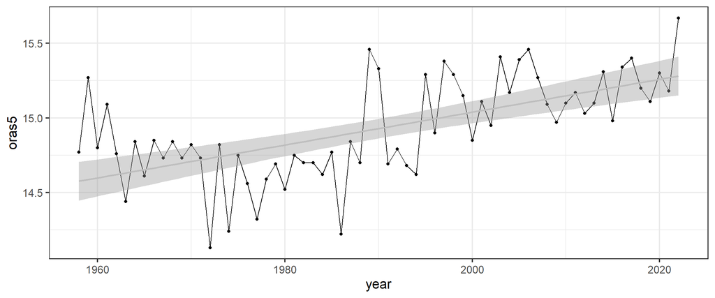

```r
# environmental data from ORAS5: 1958-2022

oras <- readRDS("C:/Use/GitHub/ices-tools-dev/SEAwise/SEAwise_T3.3/data/env/ORAS5_AnnualTEMPByDemPelStock2.RDS")
oras <- subset(oras, select=c("year", "ane.27.8"))
names(oras) <- c("year","oras5")

ggplot(oras, aes(year, oras5))+
  geom_point()+
  geom_line()+
  geom_smooth(method="lm", col="grey")
```

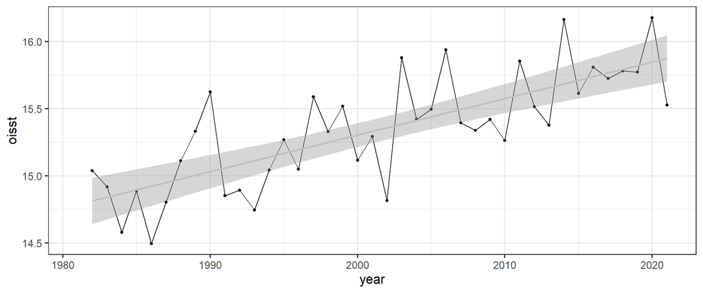

```r
# environmental data from Fernando OISST: 1981-2022

doisst <- readRDS(file.path("env_data_fernando","doisst.rds"))
doisst$tosa = with( doisst, ( tosWinter + tosSpring + tosSummer + tosAutumn ) / 4.0 )
doisst = doisst[ c( 'y', 'tosa' ) ]
names(doisst) <- c("year","oisst")

ggplot(doisst, aes(year, oisst))+
  geom_point()+
  geom_line()+
  geom_smooth(method="lm", col="grey")
```

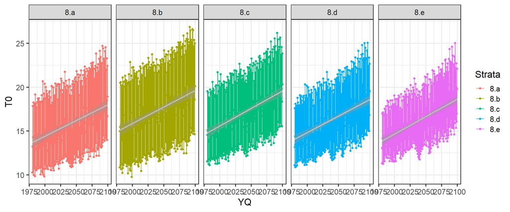

```r
# environmental data from NEMO-MEDUSA: 1980-2099 (RCP 8.5)

aux <- load("C:/Use/proyectos/IM-21-SEAWISE/wp3/env_nemomedusa/NM_series.RData")
nemomed <- get(aux[[1]])
rm(aux)

nemomed <- subset(nemomed, select=c("Year", "Quarter","YQ","Strata","T0")) %>%
  filter(Strata %in% c("8.a","8.b","8.c","8.d","8.e")) %>%
  mutate(Year=as.numeric(Year),
         Quarter=as.numeric(Quarter))

ggplot(nemomed, aes(YQ, T0, group=Strata, col=Strata))+
  geom_line()+
  geom_point()+
  facet_grid(~Strata)+
  geom_smooth(method="lm", col="grey")
```

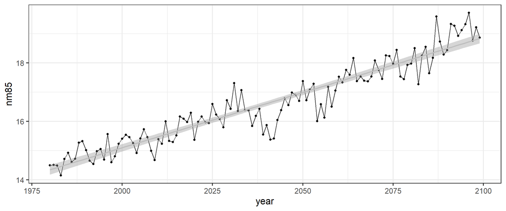

```r
nemomed <- nemomed %>%
  group_by(Year) %>%
  summarise(T0=mean(T0)) %>%
  rename(year=Year,
         nm85=T0)

ggplot(nemomed, aes(year, nm85))+
  geom_point()+
  geom_line()+
  geom_smooth(method="lm", col="grey")
```

```r
# environmental data from NEMO-MEDUSA: 1980-2099 (RCP 8.5)

polcoms.rcp45 <- readRDS("C:/Use/proyectos/IM-21-SEAWISE/wp3/env_polcoms_ersem_sst_proj/POLCOMS_sst_spt45.RDS")
polcoms.rcp45 <- as.data.frame(polcoms.rcp45)
names(polcoms.rcp45) <- c("year","pe45")
polcoms.rcp45$pe45 <- as.numeric(polcoms.rcp45$pe45)

polcoms.rcp85 <- readRDS("C:/Use/proyectos/IM-21-SEAWISE/wp3/env_polcoms_ersem_sst_proj/POLCOMS_sst_spt85.RDS")
polcoms.rcp85 <- as.data.frame(polcoms.rcp85)
names(polcoms.rcp85) <- c("year","pe85")
polcoms.rcp85$pe85 <- as.numeric(polcoms.rcp85$pe85)

# check year ranges without NA's

range(doisst$year[!is.na(doisst$oisst)])
```

```
## [1] 1982 2021
```

```r
range(oras$year[!is.na(oras$oras5)])
```

```
## [1] 1958 2022
```

```r
range(nemomed$year[!is.na(nemomed$nm85)])
```

```
## [1] 1980 2099
```

```r
range(polcoms.rcp45$year[!is.na(polcoms.rcp45$pe45)])
```

```
## [1] 2006 2099
```

```r
range(polcoms.rcp85$year[!is.na(polcoms.rcp85$pe85)])
```

```
## [1] 2006 2099
```

```r
# merge all the temperatures, remove 1981 (missing oisst)

temp.dat <- merge(doisst, oras, by="year", all=T)
temp.dat <- merge(temp.dat, nemomed, by="year", all=T)
temp.dat <- merge(temp.dat, polcoms.rcp45, by="year", all=T)
temp.dat <- merge(temp.dat, polcoms.rcp85, by="year", all=T)
temp.dat <- subset(temp.dat, year>=1980) # remove past oras data
```

We compare the temperatures from the different data sources

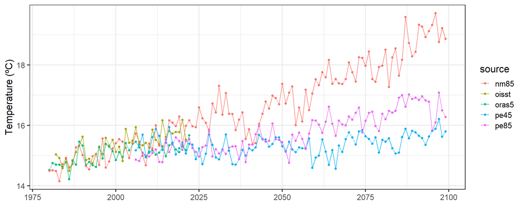

```r
# long format for ggplot plotting

temp.datl <- pivot_longer(temp.dat, cols=c("oras5","oisst","nm85","pe45","pe85"), names_to="source")

ggplot(temp.datl, aes(year, value, col=source, group=source))+
  geom_point()+
  geom_line()+
  ylab("Temperature (ºC)")+
  xlab("")
```

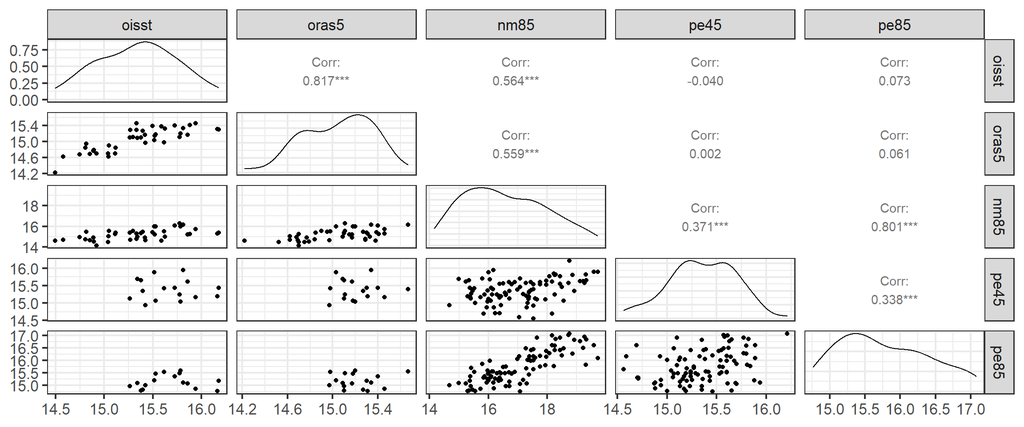

```r
ggpairs(temp.dat[, -1])
```

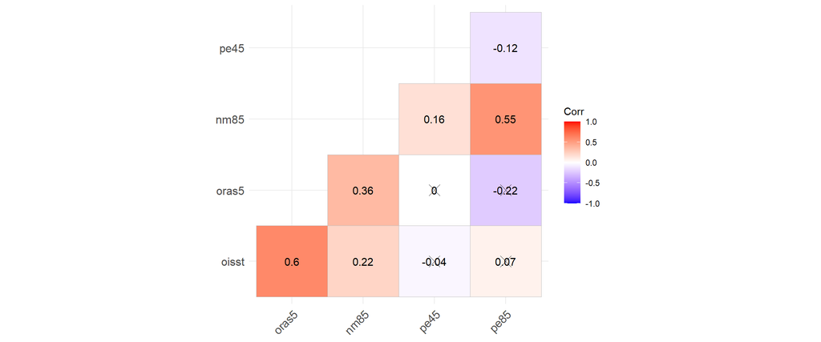

```r
mat <- cor(temp.dat[, -1], use="complete.obs")
p.mat <- cor_pmat(temp.dat[, -1])
ggcorrplot(mat, type = "lower", lab=T, p.mat = p.mat)
```

# NEMO-MEDUSA

## Delta-method

The mean-bias correction or delta method was applied to the annual time series (not by grid-cell or by month). We use as overlap the most recent overlapping period between oisst and nemo-medusa (1982-2021).

```r
# overlapping period

commonyrs <- intersect(doisst$year[!is.na(doisst$oisst)] , nemomed$year[!is.na(nemomed$nm85)])
commonyrs
```

```
##  [1] 1982 1983 1984 1985 1986 1987 1988 1989 1990 1991 1992 1993 1994 1995 1996
## [16] 1997 1998 1999 2000 2001 2002 2003 2004 2005 2006 2007 2008 2009 2010 2011
## [31] 2012 2013 2014 2015 2016 2017 2018 2019 2020 2021
```

```r
# calculate bias
bias <- mean(temp.dat$nm85[temp.dat$year %in% commonyrs]) - mean(temp.dat$oisst[temp.dat$year %in% commonyrs]) # equivalent to mean(temp.dat$nm85 -temp.dat$oisst)
bias
```

```
## [1] -0.1250588
```

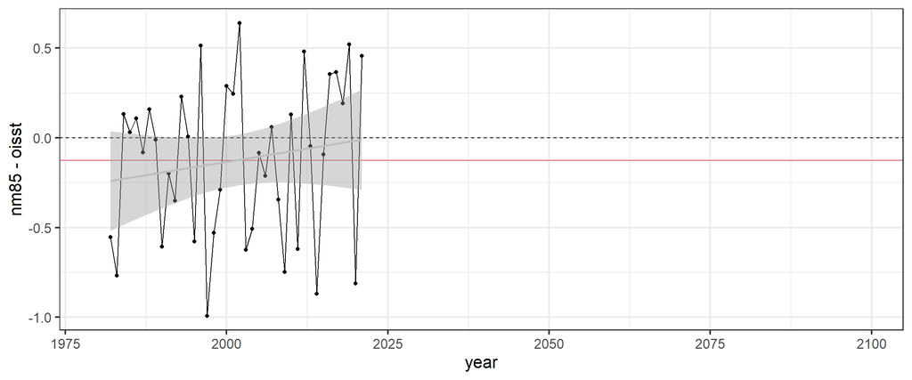

```r
ggplot(temp.dat, aes(year, nm85-oisst)) +
  geom_line()+
  geom_point()+
  geom_hline(yintercept=0, lty=2)+
  geom_hline(yintercept=bias, col=2)+
  geom_smooth(method="lm", col="grey")
```

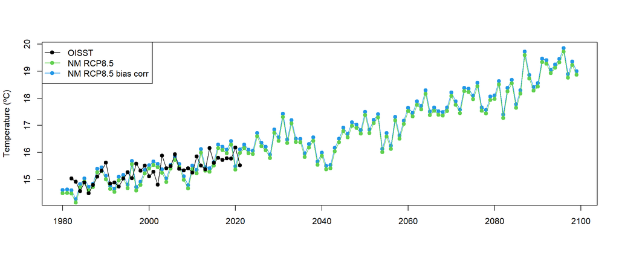

```r
# correct time series

temp.dat$nm85.bias.rm <- temp.dat$nm85 - bias
nemomed$nm85.bias.rm <- nemomed$nm85 - bias

# plots

plot(nemomed$year, nemomed$nm85.bias.rm, type="o", pch=19, col=4, xlab="", ylab="Temperature (ºC)")
lines(nemomed$year, nemomed$nm85, type="o", pch=19, col=3)
lines(temp.dat$year, temp.dat$oisst, type="o", pch=19, col=1)
legend("topleft", c("OISST","NM RCP8.5","NM RCP8.5 bias corr"), lty=1, pch=19, col=c(1,3,4))
```

# Quantile mapping method

Following the steps suggested in the tutorial:

1. decide on a time period to base the quantile mapping on - aka the ‘correction time period’ (normally the mutually overlapping period between historical data and projections, e.g. 2006 - 2020 or overlap between historical part and a control run)
2. remove the individual trends from both the historical part and projection in this ‘correction time period’
3. perform Quantile mapping on this trend-corrected data
4. remove the trend from the whole projection period (e.g. 2006 - 2100)
5. apply this fitted Qmap-model to this trend corrected data for the whole projection period
6. calculate the mean-bias (same as for the delta correction method above) for the chosen ‘correction time period’ add everything back together: the qmapped-projection - the mean bias + the projection trend

For step 2 and 3, one could use also the trend corrected data of the whole projection period and skip step 4.

```r
# overlapping period

commonyrs <- intersect(doisst$year[!is.na(doisst$oisst)] , nemomed$year[!is.na(nemomed$nm85)])
commonyrs
```

```
##  [1] 1982 1983 1984 1985 1986 1987 1988 1989 1990 1991 1992 1993 1994 1995 1996
## [16] 1997 1998 1999 2000 2001 2002 2003 2004 2005 2006 2007 2008 2009 2010 2011
## [31] 2012 2013 2014 2015 2016 2017 2018 2019 2020 2021
```

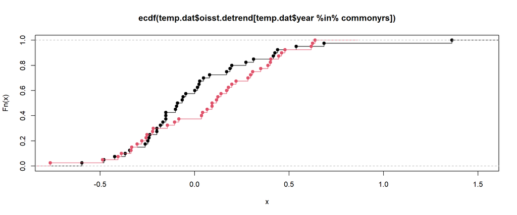

```r
# detrend the past time series

m.oisst <- lm(oisst ~ year, data=temp.dat)
m.nm <- lm(nm85 ~ year, data=nemomed) # detrend the whole time series

temp.dat$oisst.detrend <- temp.dat$oisst - predict(m.oisst)
temp.dat$nm85.detrend <- temp.dat$nm85 - predict(m.nm, newdata=temp.dat)
nemomed$nm85.detrend <- nemomed$nm85 - predict(m.nm)

# bias (same as above)
bias <- mean(temp.dat$nm85[temp.dat$year %in% commonyrs]) - mean(temp.dat$oisst[temp.dat$year %in% commonyrs])

# quantile mapping on detrended data

plot(ecdf(temp.dat$oisst.detrend[temp.dat$year %in% commonyrs]), verticals=T)
lines(ecdf(temp.dat$nm85.detrend[temp.dat$year %in% commonyrs]), col=2, verticals=T)
```

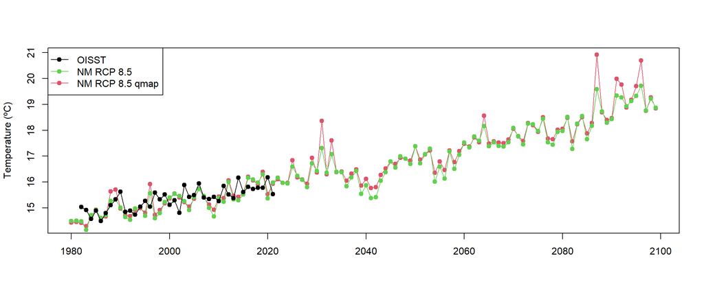

```r
# fitQmap identifyes the parameters of different quantile mapping methods
# doQmap performs quantile mapping using previously defined parameters

qmap <- fitQmap(obs = temp.dat$oisst.detrend[temp.dat$year %in% commonyrs],
               mod = temp.dat$nm85.detrend[temp.dat$year %in% commonyrs],
               method = "RQUANT",
               wet.day = F)
out <- doQmap(x = nemomed$nm85.detrend, fobj = qmap, type = "linear2")

# reconstruct series
nemomed$nm85.qmap <- out - bias + predict(m.nm, data=nemomed)
temp.dat$nm85.qmap <- nemomed$nm85.qmap[match(temp.dat$year, nemomed$year)]

# plot

plot(temp.dat$year, temp.dat$nm85.qmap, type="o", pch=19, col=2, xlab="", ylab="Temperature (ºC)")
lines(temp.dat$year, temp.dat$nm85, type="o", pch=19, col=3)
lines(temp.dat$year, temp.dat$oisst, type="o", pch=19, col=1)
legend("topleft", c("OISST","NM RCP 8.5","NM RCP 8.5 qmap"), lty=1, pch=19, col=c(1,3,2))
```

## Comparison of the two bias correction methods

In this case both methods give similar results:

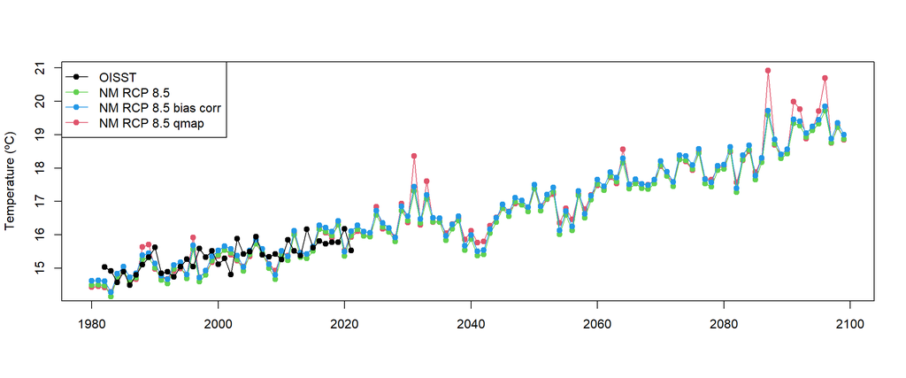

```r
plot(temp.dat$year, temp.dat$nm85.qmap, type="o", pch=19, col=2, xlab="", ylab="Temperature (ºC)")
lines(temp.dat$year, temp.dat$nm85, type="o", pch=19, col=3)
lines(temp.dat$year, temp.dat$nm85.bias.rm, type="o", pch=19, col=4)
lines(temp.dat$year, temp.dat$oisst, type="o", pch=19, col=1)
legend("topleft", c("OISST","NM RCP 8.5","NM RCP 8.5 bias corr","NM RCP 8.5 qmap"), lty=1, pch=19, col=c(1,3,4,2))
```

# POLCOMS-ERSEM RCP 4.5

## Delta-method

The mean-bias correction or delta method was applied to the annual time series (not by grid-cell or by month). We use as overlap the most recent overlapping period between oisst and polcoms (2006-2021).

```r
# overlapping period

commonyrs <- intersect(doisst$year[!is.na(doisst$oisst)] , polcoms.rcp45$year[!is.na(polcoms.rcp45$pe45)])
commonyrs
```

```
##  [1] 2006 2007 2008 2009 2010 2011 2012 2013 2014 2015 2016 2017 2018 2019 2020
## [16] 2021
```

```r
# calculate bias
bias <- mean(temp.dat$pe45[temp.dat$year %in% commonyrs]) - mean(temp.dat$oisst[temp.dat$year %in% commonyrs])
bias
```

```
## [1] -0.2813877
```

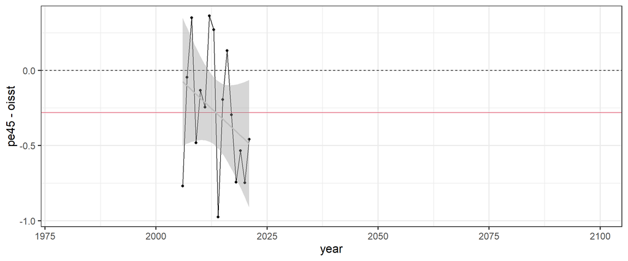

```r
ggplot(temp.dat, aes(year, pe45-oisst)) +
  geom_line()+
  geom_point()+
  geom_hline(yintercept=0, lty=2)+
  geom_hline(yintercept=bias, col=2)+
  geom_smooth(method="lm", col="grey")
```

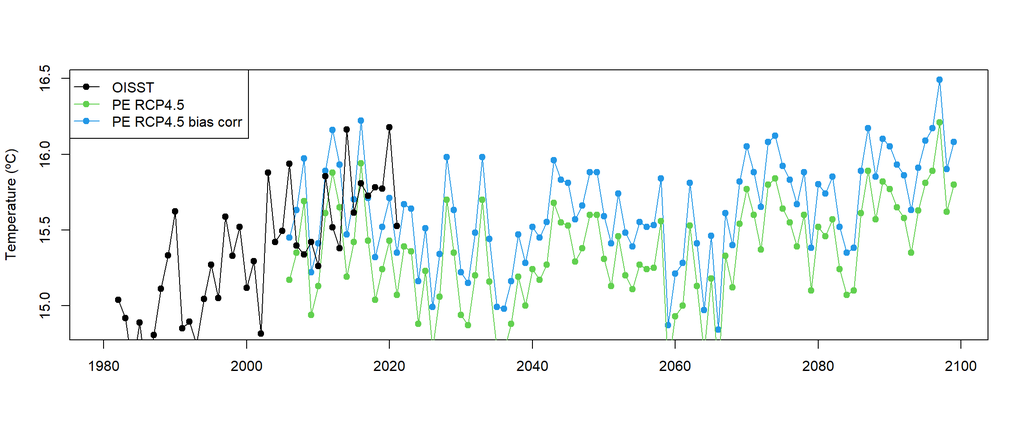

```r
# correct time series

temp.dat$pe45.bias.rm <- temp.dat$pe45 - bias
polcoms.rcp45$pe45.bias.rm <- polcoms.rcp45$pe45 - bias

# plots

plot(temp.dat$year, temp.dat$pe45.bias.rm, type="o", pch=19, col=4, xlab="", ylab="Temperature (ºC)")
lines(temp.dat$year, temp.dat$pe45, type="o", pch=19, col=3)
lines(temp.dat$year, temp.dat$oisst, type="o", pch=19, col=1)
legend("topleft", c("OISST","PE RCP4.5","PE RCP4.5 bias corr"), lty=1, pch=19, col=c(1,3,4))
```

# Quantile mapping method

Following the steps suggested in the tutorial as before for NEMO-MEDUSA data.

```r
# overlapping period

commonyrs <- intersect(doisst$year[!is.na(doisst$oisst)] , polcoms.rcp45$year[!is.na(polcoms.rcp45$pe45)])
commonyrs
```

```
##  [1] 2006 2007 2008 2009 2010 2011 2012 2013 2014 2015 2016 2017 2018 2019 2020
## [16] 2021
```

```r
# detrend the past time series

m.oisst <- lm(oisst ~ year, data=temp.dat)
m.pe45 <- lm(pe45 ~ year, data=polcoms.rcp45) # detrend the whole time series

temp.dat$oisst.detrend <- temp.dat$oisst - predict(m.oisst)
temp.dat$pe45.detrend <- temp.dat$pe45 - predict(m.pe45, newdata=temp.dat)
polcoms.rcp45$pe45.detrend <- polcoms.rcp45$pe45 - predict(m.pe45)

# bias (same as above)
bias <- mean(temp.dat$pe45[temp.dat$year %in% commonyrs]) - mean(temp.dat$oisst[temp.dat$year %in% commonyrs])
bias
```

```
## [1] -0.2813877
```

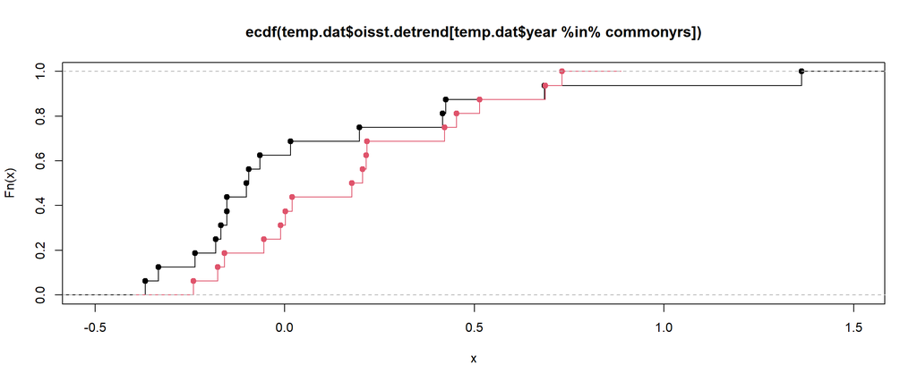

```r
# quantile mapping on detrended data

plot(ecdf(temp.dat$oisst.detrend[temp.dat$year %in% commonyrs]), verticals=T)
lines(ecdf(temp.dat$pe45.detrend[temp.dat$year %in% commonyrs]), col=2, verticals=T)
```

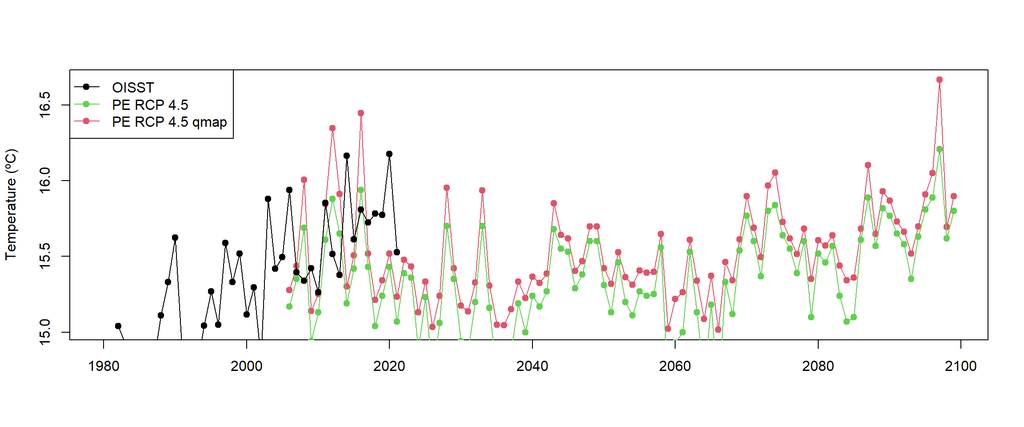

```r
# fitQmap identifyes the parameters of different quantile mapping methods
# doQmap performs quantile mapping using previously defined parameters

qmap <- fitQmap(obs = temp.dat$oisst.detrend[temp.dat$year %in% commonyrs],
               mod = temp.dat$pe45.detrend[temp.dat$year %in% commonyrs],
               method = "RQUANT",
               wet.day = F)
out <- doQmap(x = polcoms.rcp45$pe45.detrend, fobj = qmap, type = "linear2")

# reconstruct series
polcoms.rcp45$pe45.qmap <- out - bias + predict(m.pe45, data=polcoms.rcp45)
temp.dat$pe45.qmap <- polcoms.rcp45$pe45.qmap[match(temp.dat$year, polcoms.rcp45$year)]

# plot

plot(temp.dat$year, temp.dat$pe45.qmap, type="o", pch=19, col=2, xlab="", ylab="Temperature (ºC)")
lines(temp.dat$year, temp.dat$pe45, type="o", pch=19, col=3)
lines(temp.dat$year, temp.dat$oisst, type="o", pch=19, col=1)
legend("topleft", c("OISST","PE RCP 4.5","PE RCP 4.5 qmap"), lty=1, pch=19, col=c(1,3,2))
```

## Comparison of the two bias correction methods

In this case both methods give similar results:

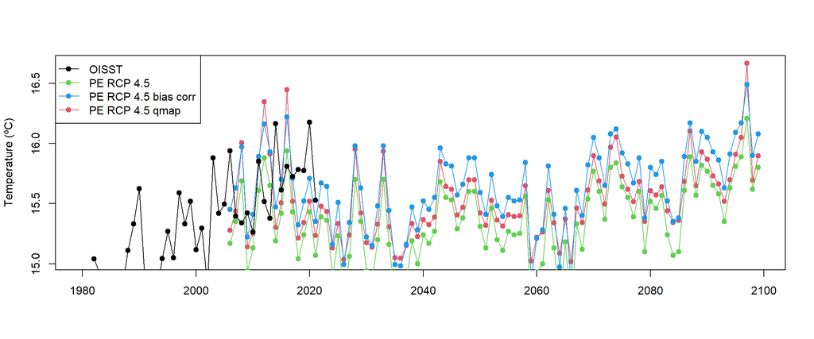

```r
plot(temp.dat$year, temp.dat$pe45.qmap, type="o", pch=19, col=2, xlab="", ylab="Temperature (ºC)")
lines(temp.dat$year, temp.dat$pe45, type="o", pch=19, col=3)
lines(temp.dat$year, temp.dat$pe45.bias.rm, type="o", pch=19, col=4)
lines(temp.dat$year, temp.dat$oisst, type="o", pch=19, col=1)
legend("topleft", c("OISST","PE RCP 4.5","PE RCP 4.5 bias corr","PE RCP 4.5 qmap"), lty=1, pch=19, col=c(1,3,4,2))
```

# POLCOMS-ERSEM RCP 8.5

## Delta-method

The mean-bias correction or delta method was applied to the annual time series (not by grid-cell or by month). We use as overlap the most recent overlapping period between oisst and polcoms (2006-2021).

```r
# overlapping period

commonyrs <- intersect(doisst$year[!is.na(doisst$oisst)] , polcoms.rcp85$year[!is.na(polcoms.rcp85$pe85)])
commonyrs
```

```
##  [1] 2006 2007 2008 2009 2010 2011 2012 2013 2014 2015 2016 2017 2018 2019 2020
## [16] 2021
```

```r
# calculate bias
bias <- mean(temp.dat$pe85[temp.dat$year %in% commonyrs]) - mean(temp.dat$oisst[temp.dat$year %in% commonyrs])
bias
```

```
## [1] -0.5201377
```

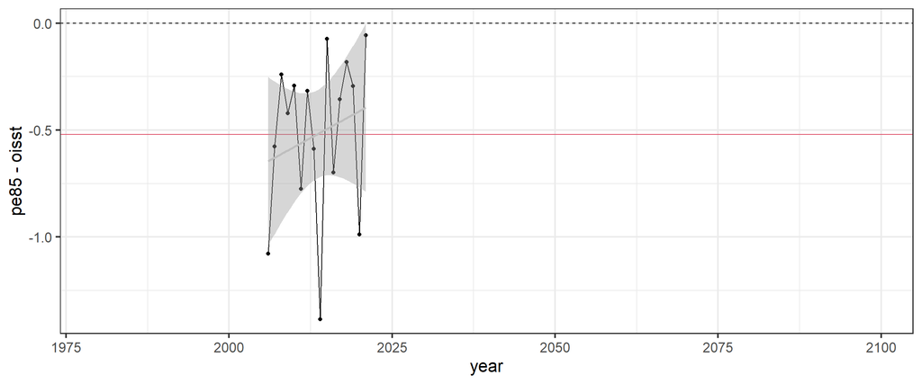

```r
ggplot(temp.dat, aes(year, pe85-oisst)) +
  geom_line()+
  geom_point()+
  geom_hline(yintercept=0, lty=2)+
  geom_hline(yintercept=bias, col=2)+
  geom_smooth(method="lm", col="grey")
```

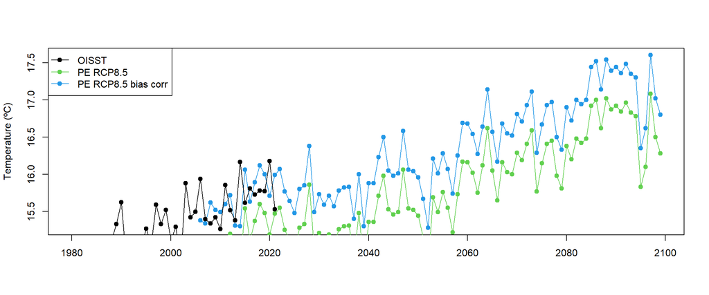

```r
# correct time series

temp.dat$pe85.bias.rm <- temp.dat$pe85 - bias
polcoms.rcp85$pe85.bias.rm <- polcoms.rcp85$pe85 - bias

# plots

plot(temp.dat$year, temp.dat$pe85.bias.rm, type="o", pch=19, col=4, xlab="", ylab="Temperature (ºC)")
lines(temp.dat$year, temp.dat$pe85, type="o", pch=19, col=3)
lines(temp.dat$year, temp.dat$oisst, type="o", pch=19, col=1)
legend("topleft", c("OISST","PE RCP8.5","PE RCP8.5 bias corr"), lty=1, pch=19, col=c(1,3,4))
```

# Quantile mapping method

Following the steps suggested in the tutorial as before for NEMO-MEDUSA data.

```r
# overlapping period

commonyrs <- intersect(doisst$year[!is.na(doisst$oisst)] , polcoms.rcp85$year[!is.na(polcoms.rcp85$pe85)])
commonyrs
```

```
##  [1] 2006 2007 2008 2009 2010 2011 2012 2013 2014 2015 2016 2017 2018 2019 2020
## [16] 2021
```

```r
# detrend the past time series

m.oisst <- lm(oisst ~ year, data=temp.dat)
m.pe85 <- lm(pe85 ~ year, data=polcoms.rcp85) # detrend the whole time series

temp.dat$oisst.detrend <- temp.dat$oisst - predict(m.oisst)
temp.dat$pe85.detrend <- temp.dat$pe85 - predict(m.pe85, newdata=temp.dat)
polcoms.rcp85$pe85.detrend <- polcoms.rcp85$pe85 - predict(m.pe85)

# bias (same as above)
bias <- mean(temp.dat$pe85[temp.dat$year %in% commonyrs]) - mean(temp.dat$oisst[temp.dat$year %in% commonyrs])
bias
```

```
## [1] -0.5201377
```

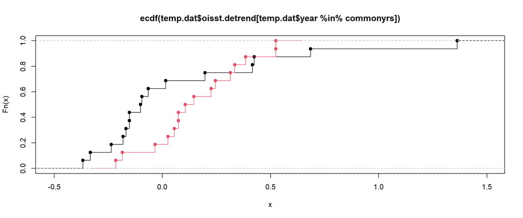

```r
# quantile mapping on detrended data

plot(ecdf(temp.dat$oisst.detrend[temp.dat$year %in% commonyrs]), verticals=T)
lines(ecdf(temp.dat$pe85.detrend[temp.dat$year %in% commonyrs]), col=2, verticals=T)
```

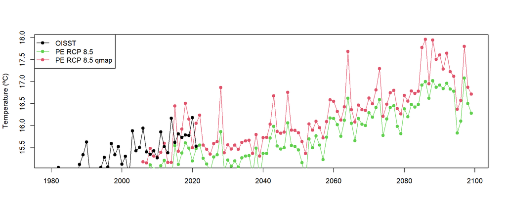

```r
# fitQmap identifyes the parameters of different quantile mapping methods
# doQmap performs quantile mapping using previously defined parameters

qmap <- fitQmap(obs = temp.dat$oisst.detrend[temp.dat$year %in% commonyrs],
               mod = temp.dat$pe85.detrend[temp.dat$year %in% commonyrs],
               method = "RQUANT",
               wet.day = F)
out <- doQmap(x = polcoms.rcp85$pe85.detrend, fobj = qmap, type = "linear2")

# reconstruct series
polcoms.rcp85$pe85.qmap <- out - bias + predict(m.pe85, data=polcoms.rcp85)
temp.dat$pe85.qmap <- polcoms.rcp85$pe85.qmap[match(temp.dat$year, polcoms.rcp85$year)]

# plot

plot(temp.dat$year, temp.dat$pe85.qmap, type="o", pch=19, col=2, xlab="", ylab="Temperature (ºC)")
lines(temp.dat$year, temp.dat$pe85, type="o", pch=19, col=3)
lines(temp.dat$year, temp.dat$oisst, type="o", pch=19, col=1)
legend("topleft", c("OISST","PE RCP 8.5","PE RCP 8.5 qmap"), lty=1, pch=19, col=c(1,3,2))
```

## Comparison of the two bias correction methods

In this case both methods give similar results:

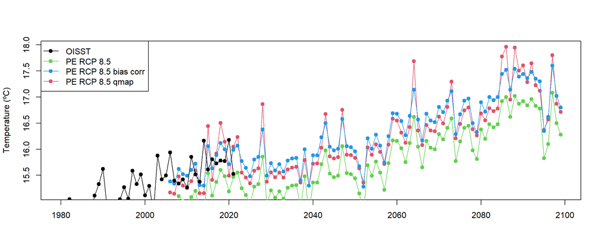

```r
plot(temp.dat$year, temp.dat$pe85.qmap, type="o", pch=19, col=2, xlab="", ylab="Temperature (ºC)")
lines(temp.dat$year, temp.dat$pe85, type="o", pch=19, col=3)
lines(temp.dat$year, temp.dat$pe85.bias.rm, type="o", pch=19, col=4)
lines(temp.dat$year, temp.dat$oisst, type="o", pch=19, col=1)
legend("topleft", c("OISST","PE RCP 8.5","PE RCP 8.5 bias corr","PE RCP 8.5 qmap"), lty=1, pch=19, col=c(1,3,4,2))
```

# Final temperature scenarios

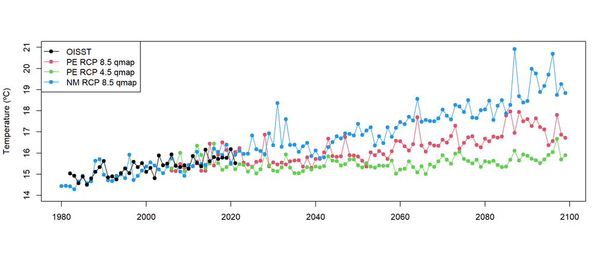

```r
plot(temp.dat$year, temp.dat$pe85.qmap, type="o", pch=19, col=2, xlab="", ylab="Temperature (ºC)", ylim=c(14,21))
lines(temp.dat$year, temp.dat$pe45.qmap, type="o", pch=19, col=3)
lines(temp.dat$year, temp.dat$nm85.qmap, type="o", pch=19, col=4)
lines(temp.dat$year, temp.dat$oisst, type="o", pch=19, col=1)
legend("topleft", c("OISST","PE RCP 8.5 qmap", "PE RCP 4.5 qmap", "NM RCP 8.5 qmap"), lty=1, pch=19, col=c(1,2,3,4))
```

# Save results

```r
names(temp.dat)
```

```
##  [1] "year"          "oisst"         "oras5"         "nm85"
##  [5] "pe45"          "pe85"          "nm85.bias.rm"  "oisst.detrend"
##  [9] "nm85.detrend"  "nm85.qmap"     "pe45.bias.rm"  "pe45.detrend"
## [13] "pe45.qmap"     "pe85.bias.rm"  "pe85.detrend"  "pe85.qmap"
```

```r
saveRDS(temp.dat, file="sst_projection.RDS")
```